# European founding — leadership backgrounds

For unicorns with a European founding footprint in this sample, **where leaders studied and worked before the company**, **how much relevant tenure they accumulate before joining**, and **how first versus highest pre-founding degrees compare** sharpen the picture relative to a global-only view. The opening charts use founding-year discipline on education dates, group-level employers where possible, and the same tenure logic as the main workbook.

The closing **Europe-founded unicorns** view compares **2023+** founders, executives, and pooled leadership with **pre-2023 matched founders** on aligned industry and geography definitions. The summary table lists **2023+ cohorts first**, with **pre-2023 matched founders** in the **right-hand column**.

## Scope and definitions

**Geography.** “Europe” uses the founding-country field from the unicorn reference; **Israel is excluded** from this slice so the geography label matches the bounded universe used elsewhere for Europe-focused work.

**Cohorts in the main charts.** Results are shown for **co-founders at unicorns founded on or before 2022**, the **2023+** matched co-founder list, the **2023+** senior executive bench where that roster applies, and an **all-founders** combination of the two founder paths (not the executive-only roster). The four-panel work view rolls up employers to **group** where possible, uses each person’s **first bachelor-level school** among education rows dated **on or before the founding year**, and reports **tenure before first joining the portfolio company** under the same role-quality filters as the broader workbook; country averages appear only where the headcount supports a stable mean.

**Degree and field.** “Highest” versus “first” pre-founding qualification uses dated education ending on or before the founding year (or starting there if an end date is missing); where the two diverge materially, it usually reflects **mid-career study** rather than a change in initial attainment.

**Europe-founded unicorns (closing block).** The final exhibits restrict to **Europe-founded unicorns** and compare **pre-2023 matched founders** with **2023+** founders, executives, and pooled leadership. Prior-role **finance** uses Revelio **RICS** (Financial Services at K10 / the associated K50 children); **academia** uses **RICS K400 = Research Universities** and drops work spells whose dates overlap **pre-founding** education so concurrent study does not inflate academic employment. **U.S. education exposure** uses **RSID_V2_COUNTRY_V3** on education rows (United States and common aliases). The summary table shows **levels only** (no percentage-point deltas): three **2023+** columns, then **pre-2023 founders** in the last column. An **“Other / unclassified”** employer bucket is omitted there because it otherwise absorbs most unlabeled history.

**Interpretation.** Executive and founder rosters are constructed differently; side-by-side contrasts are **descriptive** and should be read as texture on pipelines, not as rankings of quality.

```
Loading GE2023 founder work/edu with founding country…
Building all-founder bundle (≤2022 + GE2023 founders)…
Computing tenure until first focal unicorn (Snowflake)…
```

Europe founding — charts (all cohorts)  
Per cohort: 2×2 panel, then degree-level mix, then field-of-study mix (same as main ACCEL section).

```
(Thresholds: tenure-by-country bars use n>=3; school/employer-by-country tables use top-8 countries x top-5.)

=== Europe / Unicorn year ≤2022 — co-founders — rows work: 2983 edu: 964 ===
```

Europe founding — Unicorn year ≤2022 — co-founders  
Europe founding only · first bachelor schools, ultimate parent employers, people by founding country, tenure until focal unicorn

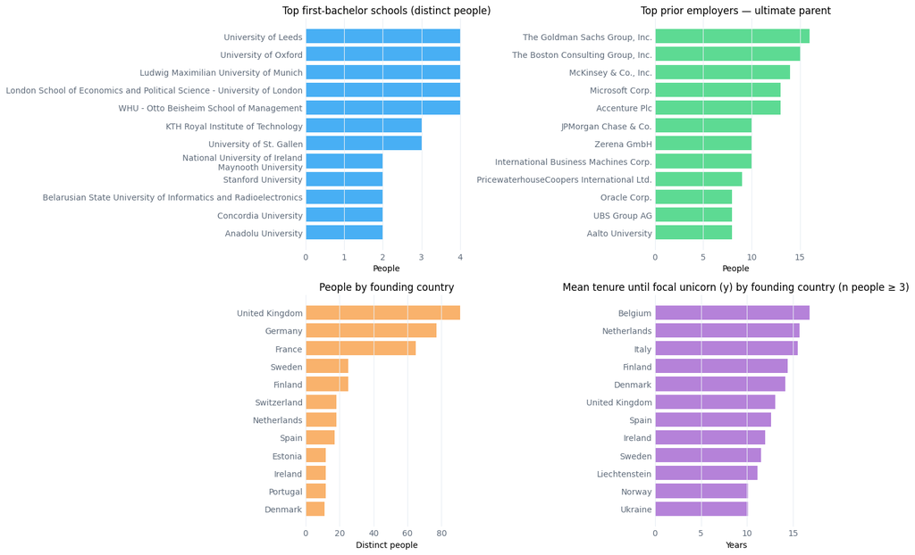

Europe · Unicorn year ≤2022 — co-founders — Degree level mix  
Among people with degree level on file; overall and by founding country — **final / highest on file**

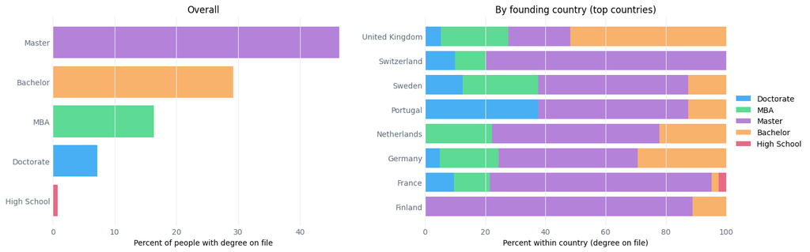

Europe · Unicorn year ≤2022 — co-founders — Degree level mix  
Among people with degree level on file; overall and by founding country — **first dated credential**

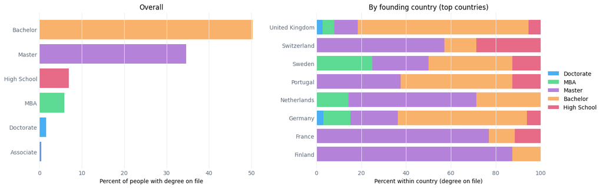

Europe · Unicorn year ≤2022 — co-founders — first vs final degree (insights)

- **Pre-founding filter:** only education rows whose **end year** (`EDU_END` / `ENDDATE`) fall on or before the CSV **`UNICORN_YEAR_FOUNDED`** are kept; if end date is missing, the **start year** must be on or before that founding year. Rows without a parseable founding year from the join are excluded from these mixes.

- **Final / highest (pre-founding)** = among those rows, the **highest** degree bucket still observed before founding. - **First dated (pre-founding)** = among those rows, the **earliest** dated credential before founding.

- **Final / highest (top buckets):** Master 46.4%, Bachelor 29.2%, MBA 16.4%

- **First dated (top buckets):** Bachelor 50.3%, Master 34.6%, High School 7.0%

- **Bachelor:** first-dated **50.3%** vs final/highest **29.2%** (Δ **-21.1** points) — often driven by later graduate study after the first credential.

- **Master:** first-dated **34.6%** vs final/highest **46.4%** (Δ **+11.8** points) — often driven by later graduate study after the first credential.

- **MBA:** first-dated **5.9%** vs final/highest **16.4%** (Δ **+10.5** points) — often driven by later graduate study after the first credential.

- **Doctorate:** first-dated **1.6%** vs final/highest **7.2%** (Δ **+5.6** points) — often driven by later graduate study after the first credential.

Europe · Unicorn year ≤2022 — co-founders — Degree field / major mix  
Non-empty fields only; overall and by founding country — **final / highest degree row field**

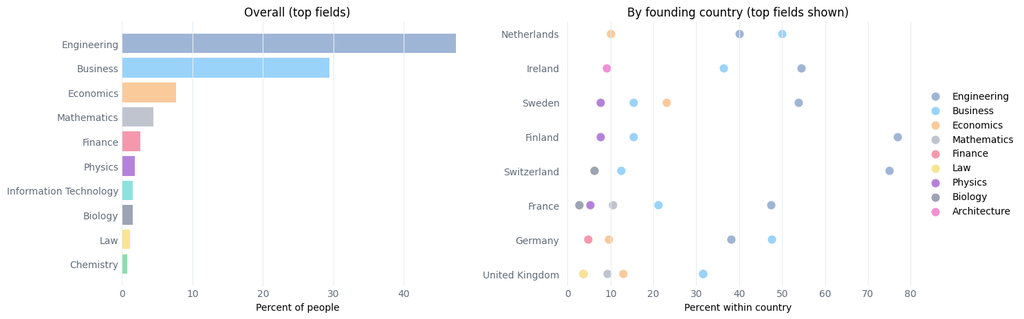

Europe · Unicorn year ≤2022 — co-founders — Degree field / major mix  
Non-empty fields only; overall and by founding country — **first dated credential**

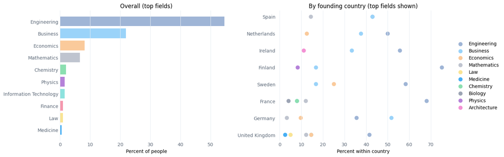

```
=== Europe / 2023+ — executive team (seniority 5–7) — rows work: 159898 edu: 34311 ===
```

Europe founding — 2023+ — executive team (seniority 5–7)  
Europe founding only · first bachelor schools, ultimate parent employers, people by founding country, tenure until focal unicorn

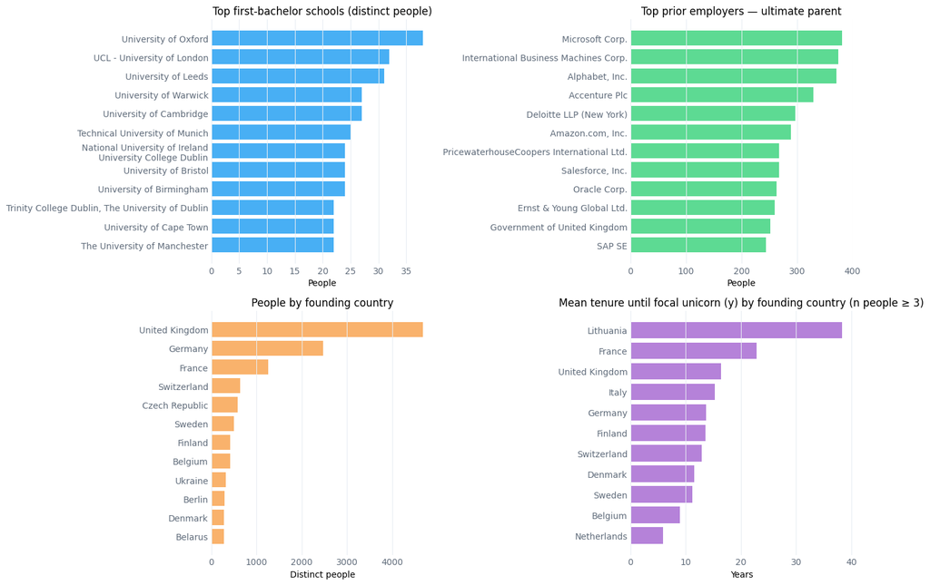

Europe · 2023+ — executive team (seniority 5–7) — Degree level mix  
Among people with degree level on file; overall and by founding country — **final / highest on file**

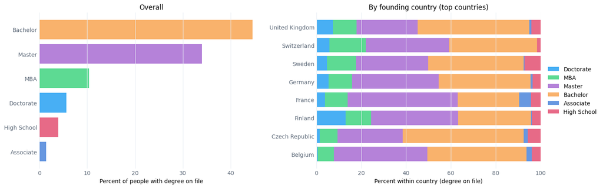

Europe · 2023+ — executive team (seniority 5–7) — Degree level mix  
Among people with degree level on file; overall and by founding country — **first dated credential**

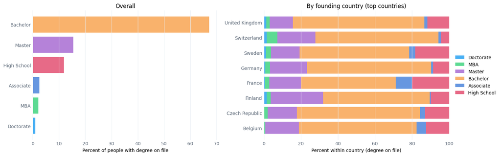

Europe · 2023+ — executive team (seniority 5–7) — first vs final degree (insights)

- **Pre-founding filter:** only education rows whose **end year** (`EDU_END` / `ENDDATE`) fall on or before the CSV **`UNICORN_YEAR_FOUNDED`** are kept; if end date is missing, the **start year** must be on or before that founding year. Rows without a parseable founding year from the join are excluded from these mixes.

- **Final / highest (pre-founding)** = among those rows, the **highest** degree bucket still observed before founding. - **First dated (pre-founding)** = among those rows, the **earliest** dated credential before founding.

- **Final / highest (top buckets):** Bachelor 44.6%, Master 34.0%, MBA 10.4%

- **First dated (top buckets):** Bachelor 67.1%, Master 15.5%, High School 11.9%

- **Bachelor:** first-dated **67.1%** vs final/highest **44.6%** (Δ **-22.5** points) — often driven by later graduate study after the first credential.

- **Master:** first-dated **15.5%** vs final/highest **34.0%** (Δ **+18.5** points) — often driven by later graduate study after the first credential.

- **MBA:** first-dated **2.1%** vs final/highest **10.4%** (Δ **+8.3** points) — often driven by later graduate study after the first credential.

- **Doctorate:** first-dated **1.0%** vs final/highest **5.7%** (Δ **+4.7** points) — often driven by later graduate study after the first credential.

Europe · 2023+ — executive team (seniority 5–7) — Degree field / major mix  
Non-empty fields only; overall and by founding country — **final / highest degree row field**

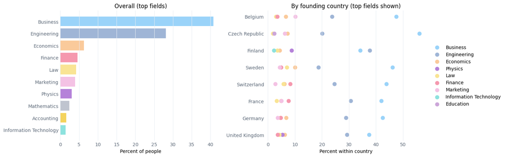

Europe · 2023+ — executive team (seniority 5–7) — Degree field / major mix  
Non-empty fields only; overall and by founding country — **first dated credential**

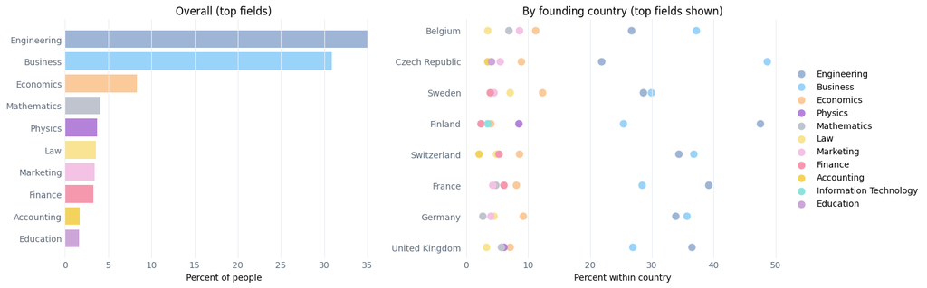

```
=== Europe / 2023+ — matched CSV co-founders — rows work: 885 edu: 318 ===
```

Europe founding — 2023+ — matched CSV co-founders  
Europe founding only · first bachelor schools, ultimate parent employers, people by founding country, tenure until focal unicorn

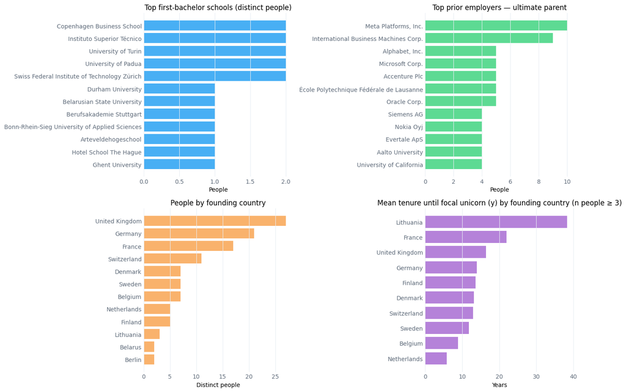

Europe · 2023+ — matched CSV co-founders — Degree level mix  
Among people with degree level on file; overall and by founding country — **final / highest on file**

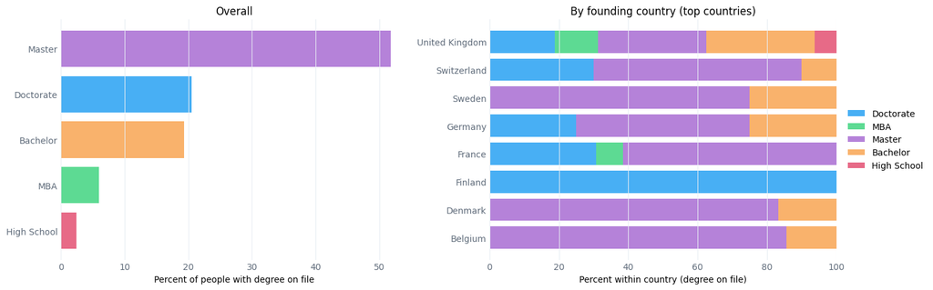

Europe · 2023+ — matched CSV co-founders — Degree level mix  
Among people with degree level on file; overall and by founding country — **first dated credential**

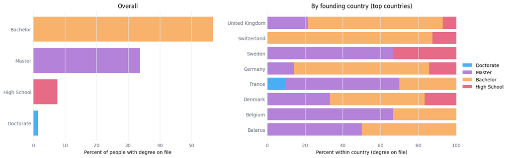

Europe · 2023+ — matched CSV co-founders — first vs final degree (insights)

- **Pre-founding filter:** only education rows whose **end year** (`EDU_END` / `ENDDATE`) fall on or before the CSV **`UNICORN_YEAR_FOUNDED`** are kept; if end date is missing, the **start year** must be on or before that founding year. Rows without a parseable founding year from the join are excluded from these mixes.

- **Final / highest (pre-founding)** = among those rows, the **highest** degree bucket still observed before founding. - **First dated (pre-founding)** = among those rows, the **earliest** dated credential before founding.

- **Final / highest (top buckets):** Master 51.8%, Doctorate 20.5%, Bachelor 19.3%

- **First dated (top buckets):** Bachelor 56.9%, Master 33.8%, High School 7.7%

- **Bachelor:** first-dated **56.9%** vs final/highest **19.3%** (Δ **-37.6** points) — often driven by later graduate study after the first credential.

- **Master:** first-dated **33.8%** vs final/highest **51.8%** (Δ **+18.0** points) — often driven by later graduate study after the first credential.

- **MBA:** first-dated **0.0%** vs final/highest **6.0%** (Δ **+6.0** points) — often driven by later graduate study after the first credential.

- **Doctorate:** first-dated **1.5%** vs final/highest **20.5%** (Δ **+19.0** points) — often driven by later graduate study after the first credential.

Europe · 2023+ — matched CSV co-founders — Degree field / major mix  
Non-empty fields only; overall and by founding country — **final / highest degree row field**

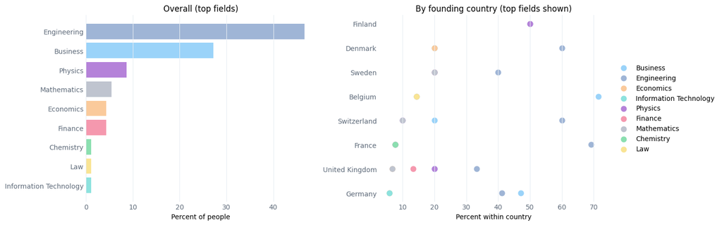

Europe · 2023+ — matched CSV co-founders — Degree field / major mix  
Non-empty fields only; overall and by founding country — **first dated credential**

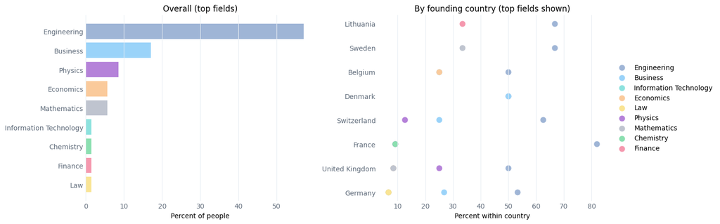

```
=== Europe / All founders/co-founders (≤2022 + GE2023 founders, no execs) — rows work: 3964 edu: 1338 ===
```

Europe founding — All founders/co-founders (≤2022 + GE2023 founders, no execs)  
Europe founding only · first bachelor schools, ultimate parent employers, people by founding country, tenure until focal unicorn

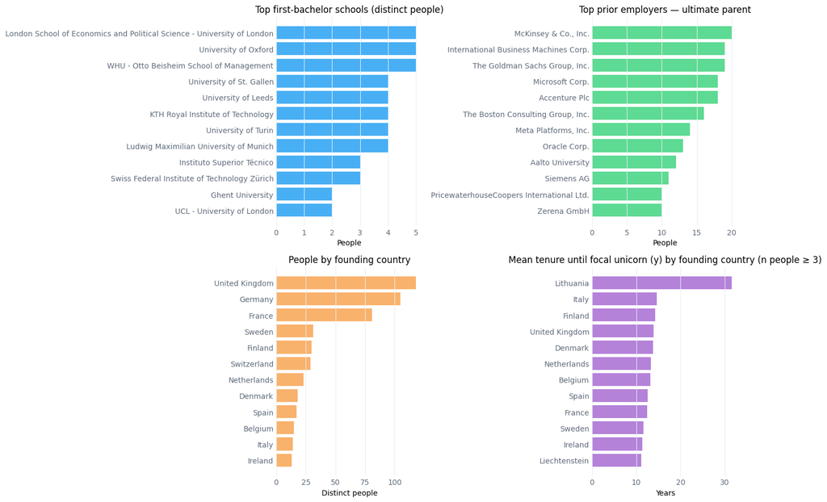

Europe · All founders/co-founders (≤2022 + GE2023 founders, no execs) — Degree level mix  
Among people with degree level on file; overall and by founding country — **final / highest on file**

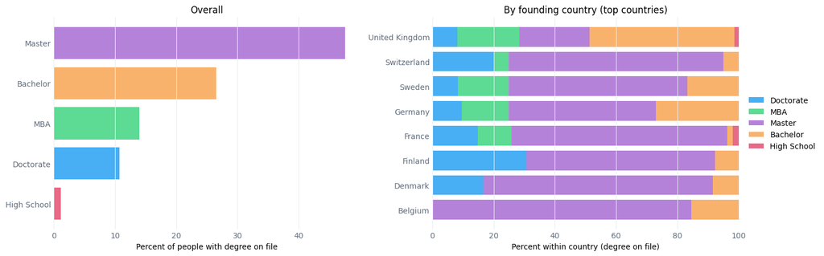

Europe · All founders/co-founders (≤2022 + GE2023 founders, no execs) — Degree level mix  
Among people with degree level on file; overall and by founding country — **first dated credential**

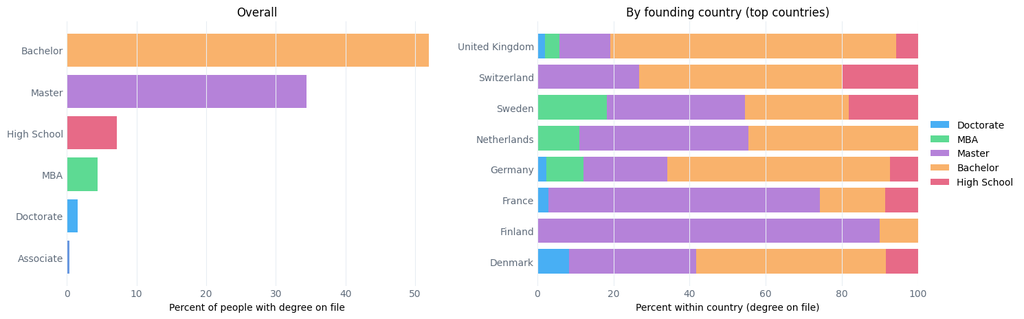

Europe · All founders/co-founders (≤2022 + GE2023 founders, no execs) — first vs final degree (insights)

- **Pre-founding filter:** only education rows whose **end year** (`EDU_END` / `ENDDATE`) fall on or before the CSV **`UNICORN_YEAR_FOUNDED`** are kept; if end date is missing, the **start year** must be on or before that founding year. Rows without a parseable founding year from the join are excluded from these mixes.

- **Final / highest (pre-founding)** = among those rows, the **highest** degree bucket still observed before founding. - **First dated (pre-founding)** = among those rows, the **earliest** dated credential before founding.

- **Final / highest (top buckets):** Master 47.6%, Bachelor 26.5%, MBA 14.0%

- **First dated (top buckets):** Bachelor 52.0%, Master 34.4%, High School 7.2%

- **Bachelor:** first-dated **52.0%** vs final/highest **26.5%** (Δ **-25.5** points) — often driven by later graduate study after the first credential.

- **Master:** first-dated **34.4%** vs final/highest **47.6%** (Δ **+13.2** points) — often driven by later graduate study after the first credential.

- **MBA:** first-dated **4.4%** vs final/highest **14.0%** (Δ **+9.6** points) — often driven by later graduate study after the first credential.

- **Doctorate:** first-dated **1.6%** vs final/highest **10.7%** (Δ **+9.1** points) — often driven by later graduate study after the first credential.

Europe · All founders/co-founders (≤2022 + GE2023 founders, no execs) — Degree field / major mix  
Non-empty fields only; overall and by founding country — **final / highest degree row field**

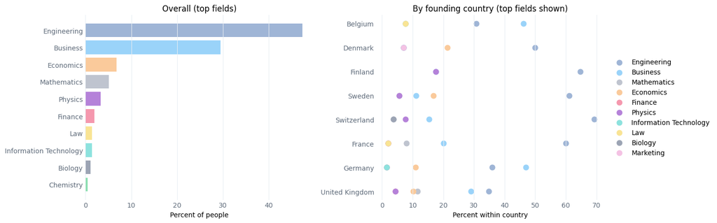

Europe · All founders/co-founders (≤2022 + GE2023 founders, no execs) — Degree field / major mix  
Non-empty fields only; overall and by founding country — **first dated credential**

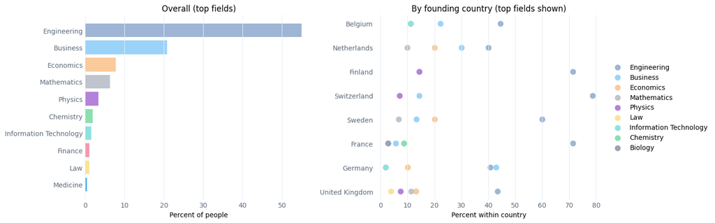

Europe founding — tables (all cohorts)  
Employer lists, school drilldowns, and pair-level tenure summaries.

```
=== Europe / Unicorn year ≤2022 — co-founders — rows work: 2983 edu: 964 ===
```

Europe founding — Unicorn year ≤2022 — co-founders (tables)  
Ultimate parent employers · first bachelor schools by founding country

```
Top prior employers (ultimate parent) — Europe · Unicorn year ≤2022 — co-founders
```

|  | employer_label | n_people |
| --- | --- | --- |
| 1446 | The Goldman Sachs Group, Inc. | 16 |
| 1435 | The Boston Consulting Group, Inc. | 15 |
| 902 | McKinsey & Co., Inc. | 14 |
| 920 | Microsoft Corp. | 13 |
| 34 | Accenture Plc | 13 |
| 755 | JPMorgan Chase & Co. | 10 |
| 1671 | Zerena GmbH | 10 |
| 747 | International Business Machines Corp. | 10 |
| 1121 | PricewaterhouseCoopers International Ltd. | 9 |
| 1042 | Oracle Corp. | 8 |
| 1506 | UBS Group AG | 8 |
| 28 | Aalto University | 8 |
| 1280 | Siemens AG | 7 |
| 1126 | Procter & Gamble Co. | 7 |
| 405 | DoorDash, Inc. | 7 |

```
Top first-bachelor schools by founding country — Europe · Unicorn year ≤2022 — co-founders
```

|  | FOUNDING_COUNTRY | school | n_people |
| --- | --- | --- | --- |
| 0 | United Kingdom | University of Oxford | 4 |
| 1 | United Kingdom | University of Leeds | 4 |
| 2 | United Kingdom | UCL - University of London | 2 |
| 3 | United Kingdom | University of Wisconsin-Madison | 2 |
| 4 | United Kingdom | Cardiff University | 1 |
| 5 | Germany | WHU - Otto Beisheim School of Management | 4 |
| 6 | Germany | Ludwig Maximilian University of Munich | 3 |
| 7 | Germany | Concordia University | 2 |
| 8 | Germany | HTWG Konstanz - University of Applied Sciences | 1 |
| 9 | Germany | Hasso-Plattner-Institut für Digital Engineerin... | 1 |
| 10 | Turkey | Anadolu University | 2 |
| 11 | Turkey | London School of Economics and Political Scien... | 2 |
| 12 | Turkey | Bilkent University | 1 |
| 13 | Turkey | Boğaziçi University | 1 |
| 14 | Turkey | Istanbul Technical University | 1 |
| 15 | Ireland | National University of Ireland\nMaynooth Unive... | 2 |
| 16 | Ireland | Trinity College Dublin, The University of Dublin | 2 |
| 17 | Ireland | National University of Ireland\nUniversity Col... | 1 |
| 18 | Ireland | National University of Ireland\nUniversity Col... | 1 |
| 19 | France | EPITA | 1 |
| 20 | France | Institut polytechnique de Paris\nEcole polytec... | 1 |
| 21 | France | Konkuk University | 1 |
| 22 | France | Lycée Henri Iv | 1 |
| 23 | France | University of Monterrey | 1 |
| 24 | Sweden | KTH Royal Institute of Technology | 3 |
| 25 | Sweden | Chalmers University of Technology | 1 |
| 26 | Sweden | University of Colorado-Boulder | 1 |
| 27 | Portugal | Instituto Superior Técnico | 1 |
| 28 | Portugal | New University of Lisbon | 1 |
| 29 | Portugal | University of Amsterdam | 1 |
| 30 | Portugal | University of Coimbra | 1 |
| 31 | Ukraine | International Christian University | 1 |
| 32 | Ukraine | National Aviation University | 1 |
| 33 | Ukraine | University of Twente | 1 |
| 34 | Ukraine | Vienna University of Economics & Business | 1 |

```
Top prior employers (ultimate parent) by founding country — Europe · Unicorn year ≤2022 — co-founders
```

|  | FOUNDING_COUNTRY | employer | n_people |
| --- | --- | --- | --- |
| 0 | United Kingdom | JPMorgan Chase & Co. | 8 |
| 1 | United Kingdom | The Goldman Sachs Group, Inc. | 6 |
| 2 | United Kingdom | McKinsey & Co., Inc. | 6 |
| 3 | United Kingdom | Starling Bank Ltd. | 4 |
| 4 | United Kingdom | University of Cambridge | 4 |
| 5 | Germany | Zerena GmbH | 8 |
| 6 | Germany | Siemens AG | 6 |
| 7 | Germany | The Goldman Sachs Group, Inc. | 5 |
| 8 | Germany | Personio Foundation | 4 |
| 9 | Germany | Founders For Good Ltd. | 4 |
| 10 | France | Dassault Systèmes SE | 5 |
| 11 | France | TripAdvisor, Inc. | 3 |
| 12 | France | eFounders SA | 3 |
| 13 | France | The Goldman Sachs Group, Inc. | 3 |
| 14 | France | Renault SA | 3 |
| 15 | Finland | Aalto University | 8 |
| 16 | Finland | Digital Chocolate, Inc. | 5 |
| 17 | Finland | F-Secure Oyj | 4 |
| 18 | Finland | Slush Oy | 4 |
| 19 | Finland | Nokia Oyj | 4 |
| 20 | Sweden | Sweet Capital Ltd. | 4 |
| 21 | Sweden | Accenture Plc | 3 |
| 22 | Sweden | SBI Holdings Corp. | 3 |
| 23 | Sweden | Försvarsmakten | 2 |
| 24 | Sweden | Gustav Erik Niklas Adalberth, | 2 |
| 25 | Switzerland | Swiss Federal Institute of Technology | 3 |
| 26 | Switzerland | UBS Group AG | 2 |
| 27 | Switzerland | Project Switzerland | 2 |
| 28 | Switzerland | International Business Machines Corp. | 2 |
| 29 | Switzerland | École Polytechnique Fédérale de Lausanne | 2 |
| 30 | Netherlands | Jteam | 2 |
| 31 | Netherlands | Procter & Gamble Co. | 2 |
| 32 | Netherlands | People For People Foundation | 2 |
| 33 | Netherlands | Rezolve AI Plc | 2 |
| 34 | Netherlands | Sia Zz Dats | 2 |
| 35 | Spain | The Boston Consulting Group, Inc. | 3 |
| 36 | Spain | Endeavor Global, Inc. | 2 |
| 37 | Spain | Itnig Solutions SL | 2 |
| 38 | Spain | Camalize SL | 2 |
| 39 | Spain | Telefónica SA | 2 |

```
Tenure until focal unicorn — summary (Europe founding · Unicorn year ≤2022 — co-founders)
n pairs: 423  mean years: 11.22588081323877  median years: 8.659822

=== Europe / 2023+ — executive team (seniority 5–7) — rows work: 159898 edu: 34311 ===
```

Europe founding — 2023+ — executive team (seniority 5–7) (tables)  
Ultimate parent employers · first bachelor schools by founding country

```
Top prior employers (ultimate parent) — Europe · 2023+ — executive team (seniority 5–7)
```

|  | employer_label | n_people |
| --- | --- | --- |
| 23959 | Microsoft Corp. | 381 |
| 19003 | International Business Machines Corp. | 374 |
| 2062 | Alphabet, Inc. | 371 |
| 1059 | Accenture Plc | 329 |
| 10151 | Deloitte LLP (New York) | 297 |
| 2214 | Amazon.com, Inc. | 289 |
| 29256 | PricewaterhouseCoopers International Ltd. | 268 |
| 32223 | Salesforce, Inc. | 267 |
| 27107 | Oracle Corp. | 263 |
| 12297 | Ernst & Young Global Ltd. | 260 |
| 15698 | Government of United Kingdom | 252 |
| 31688 | SAP SE | 244 |
| 20031 | KPMG International Cooperative | 228 |
| 15704 | Government of the United States of America | 219 |
| 38965 | UBS Group AG | 212 |

```
Top first-bachelor schools by founding country — Europe · 2023+ — executive team (seniority 5–7)
```

|  | FOUNDING_COUNTRY | school | n_people |
| --- | --- | --- | --- |
| 0 | United Kingdom | University of Leeds | 24 |
| 1 | United Kingdom | University of Oxford | 23 |
| 2 | United Kingdom | University of Warwick | 22 |
| 3 | United Kingdom | University of Birmingham | 19 |
| 4 | United Kingdom | UCL - University of London | 19 |
| 5 | Germany | Technical University of Munich | 20 |
| 6 | Germany | WHU - Otto Beisheim School of Management | 7 |
| 7 | Germany | Baden-Wuerttemberg Cooperative State Universit... | 7 |
| 8 | Germany | University of Oxford | 6 |
| 9 | Germany | RWTH Aachen University | 6 |
| 10 | France | Sciences Po Paris | 9 |
| 11 | France | University of Central Florida | 6 |
| 12 | France | PSL University\nParis-Dauphine University | 4 |
| 13 | France | London School of Economics and Political Scien... | 4 |
| 14 | France | Sorbonne University | 4 |
| 15 | Switzerland | University of St. Gallen | 13 |
| 16 | Switzerland | Swiss Federal Institute of Technology Zürich | 7 |
| 17 | Switzerland | University of Zurich | 6 |
| 18 | Switzerland | Nanyang Technological University | 5 |
| 19 | Switzerland | National University of Singapore | 5 |
| 20 | Sweden | Stockholm School of Economics | 9 |
| 21 | Sweden | Stockholm University | 6 |
| 22 | Sweden | King's College London - University of London | 4 |
| 23 | Sweden | Lund University | 3 |
| 24 | Sweden | Stanford University | 3 |
| 25 | Czech Republic | Charles University | 5 |
| 26 | Czech Republic | NHL Stenden University of Applied Sciences | 3 |
| 27 | Czech Republic | Johnson and Wales University-Providence | 3 |
| 28 | Czech Republic | Hotel School The Hague | 3 |
| 29 | Czech Republic | Trinity College Dublin, The University of Dublin | 3 |
| 30 | Finland | Warsaw University of Technology | 3 |
| 31 | Finland | Aalto University | 2 |
| 32 | Finland | California State University, Fullerton | 2 |
| 33 | Finland | Helsingin kauppakorkeakoulu | 2 |
| 34 | Finland | Metropolia University of Applied Sciences | 2 |
| 35 | Belgium | Ghent University | 9 |
| 36 | Belgium | Arteveldehogeschool | 5 |
| 37 | Belgium | Cornell University | 4 |
| 38 | Belgium | Hotel School The Hague | 3 |
| 39 | Belgium | Katholieke Universiteit Leuven Law School | 3 |

```
Top prior employers (ultimate parent) by founding country — Europe · 2023+ — executive team (seniority 5–7)
```

|  | FOUNDING_COUNTRY | employer | n_people |
| --- | --- | --- | --- |
| 0 | United Kingdom | Government of United Kingdom | 158 |
| 1 | United Kingdom | Alphabet, Inc. | 133 |
| 2 | United Kingdom | Microsoft Corp. | 127 |
| 3 | United Kingdom | Accenture Plc | 123 |
| 4 | United Kingdom | Amazon.com, Inc. | 122 |
| 5 | Germany | SAP SE | 135 |
| 6 | Germany | International Business Machines Corp. | 72 |
| 7 | Germany | Government of Germany | 69 |
| 8 | Germany | Microsoft Corp. | 67 |
| 9 | Germany | Volkswagen AG | 65 |
| 10 | France | Government of France | 66 |
| 11 | France | Microsoft Corp. | 48 |
| 12 | France | Alphabet, Inc. | 45 |
| 13 | France | Salesforce, Inc. | 42 |
| 14 | France | International Business Machines Corp. | 42 |
| 15 | Switzerland | UBS Group AG | 84 |
| 16 | Switzerland | International Business Machines Corp. | 29 |
| 17 | Switzerland | Accenture Plc | 29 |
| 18 | Switzerland | Cisco Systems, Inc. | 22 |
| 19 | Switzerland | Government of Switzerland | 21 |
| 20 | Czech Republic | Marriott International, Inc. | 27 |
| 21 | Czech Republic | Expedia Group, Inc. | 20 |
| 22 | Czech Republic | Accor SA | 19 |
| 23 | Czech Republic | Hilton Worldwide Holdings, Inc. | 18 |
| 24 | Czech Republic | Oracle Corp. | 16 |
| 25 | Sweden | McKinsey & Co., Inc. | 34 |
| 26 | Sweden | The Boston Consulting Group, Inc. | 28 |
| 27 | Sweden | Klarna Group Plc | 27 |
| 28 | Sweden | Alphabet, Inc. | 27 |
| 29 | Sweden | Spotify Technology SA | 26 |
| 30 | Finland | Nokia Oyj | 39 |
| 31 | Finland | Government of Finland | 27 |
| 32 | Finland | Aalto University | 25 |
| 33 | Finland | Microsoft Corp. | 21 |
| 34 | Finland | Government of the United States of America | 20 |
| 35 | Belgium | Lighthouse Intelligence Ltd. | 27 |
| 36 | Belgium | Marriott International, Inc. | 23 |
| 37 | Belgium | Booking Holdings, Inc. | 23 |
| 38 | Belgium | Hilton Worldwide Holdings, Inc. | 17 |
| 39 | Belgium | Expedia Group, Inc. | 17 |

```
Tenure until focal unicorn — summary (Europe founding · 2023+ — executive team (seniority 5–7))
n pairs: 135  mean years: 14.612497785185186  median years: 11.756331

=== Europe / 2023+ — matched CSV co-founders — rows work: 885 edu: 318 ===
```

Europe founding — 2023+ — matched CSV co-founders (tables)  
Ultimate parent employers · first bachelor schools by founding country

```
Top prior employers (ultimate parent) — Europe · 2023+ — matched CSV co-founders
```

|  | employer_label | n_people |
| --- | --- | --- |
| 266 | Meta Platforms, Inc. | 10 |
| 217 | International Business Machines Corp. | 9 |
| 16 | Alphabet, Inc. | 5 |
| 267 | Microsoft Corp. | 5 |
| 7 | Accenture Plc | 5 |
| 509 | École Polytechnique Fédérale de Lausanne | 5 |
| 303 | Oracle Corp. | 5 |
| 363 | Siemens AG | 4 |
| 292 | Nokia Oyj | 4 |
| 145 | Evertale ApS | 4 |
| 5 | Aalto University | 4 |
| 440 | University of California | 4 |
| 34 | BNP Paribas SA | 3 |
| 42 | Bayerische Motoren Werke AG | 3 |
| 105 | Depictai AB | 3 |

```
Top first-bachelor schools by founding country — Europe · 2023+ — matched CSV co-founders
```

|  | FOUNDING_COUNTRY | school | n_people |
| --- | --- | --- | --- |
| 0 | Switzerland | Swiss Federal Institute of Technology Zürich | 2 |
| 1 | Switzerland | Massachusetts Institute of Technology | 1 |
| 2 | Switzerland | London School of Economics and Political Scien... | 1 |
| 3 | Switzerland | Moscow Institute of Physics and Technology (Na... | 1 |
| 4 | Switzerland | National University of Science and Technology ... | 1 |
| 5 | United Kingdom | Copenhagen Business School | 1 |
| 6 | United Kingdom | Durham University | 1 |
| 7 | United Kingdom | Falmouth University | 1 |
| 8 | United Kingdom | IT University of Copenhagen | 1 |
| 9 | United Kingdom | Manchester Metropolitan University | 1 |
| 10 | Germany | Berufsakademie Stuttgart | 1 |
| 11 | Germany | Bonn-Rhein-Sieg University of Applied Sciences | 1 |
| 12 | Germany | Fontys Venlo University of Applied Sciences | 1 |
| 13 | Germany | Maastricht University | 1 |
| 14 | Germany | Technical University of Munich | 1 |
| 15 | France | Sciences Po Paris | 1 |
| 16 | France | Shanghai Jiao Tong University | 1 |
| 17 | France | University of Illinois at Urbana-Champaign | 1 |
| 18 | France | Université de Bordeaux | 1 |
| 19 | Denmark | University of Padua | 2 |
| 20 | Denmark | Copenhagen Business School | 1 |
| 21 | Denmark | University of Turin | 1 |
| 22 | Belgium | Arteveldehogeschool | 1 |
| 23 | Belgium | Ghent University | 1 |
| 24 | Belgium | University of Namur | 1 |
| 25 | Sweden | KTH Royal Institute of Technology | 1 |
| 26 | Sweden | Stockholm School of Economics | 1 |
| 27 | Sweden | The Hong Kong University of Science and Techno... | 1 |
| 28 | Netherlands | University of Amsterdam | 1 |
| 29 | Netherlands | Utrecht University | 1 |

```
Top prior employers (ultimate parent) by founding country — Europe · 2023+ — matched CSV co-founders
```

|  | FOUNDING_COUNTRY | employer | n_people |
| --- | --- | --- | --- |
| 0 | United Kingdom | Accenture Plc | 2 |
| 1 | United Kingdom | Barclays PLC | 2 |
| 2 | United Kingdom | BVNK Holdings Ltd. | 2 |
| 3 | United Kingdom | BNP Paribas SA | 2 |
| 4 | United Kingdom | Founders A/S | 2 |
| 5 | Germany | International Business Machines Corp. | 5 |
| 6 | Germany | Government of Germany | 3 |
| 7 | Germany | codecentric AG | 3 |
| 8 | Germany | Siemens AG | 3 |
| 9 | Germany | SAP SE | 3 |
| 10 | France | Meta Platforms, Inc. | 6 |
| 11 | France | Alphabet, Inc. | 3 |
| 12 | France | New York University | 3 |
| 13 | France | SLB Ltd. | 3 |
| 14 | France | McGill University | 2 |
| 15 | Switzerland | École Polytechnique Fédérale de Lausanne | 5 |
| 16 | Switzerland | Accenture Plc | 2 |
| 17 | Switzerland | International Business Machines Corp. | 2 |
| 18 | Switzerland | Oracle Corp. | 2 |
| 19 | Switzerland | Swiss Federal Institute of Technology | 2 |
| 20 | Denmark | Evertale ApS | 4 |
| 21 | Denmark | DTU Fotonik | 2 |
| 22 | Denmark | Government of Norway | 2 |
| 23 | Denmark | TDC Holding A/S | 2 |
| 24 | Denmark | Storytel AB | 2 |
| 25 | Sweden | Depictai AB | 3 |
| 26 | Sweden | ABB Ltd. | 1 |
| 27 | Sweden | Ampfield Holding AB | 1 |
| 28 | Sweden | Alphabet, Inc. | 1 |
| 29 | Sweden | Astrid Education AB | 1 |
| 30 | Belgium | Exact Holding BV | 2 |
| 31 | Belgium | AREA42 | 1 |
| 32 | Belgium | Anheuser-Busch InBev NV | 1 |
| 33 | Belgium | Belgian Maintenance Association | 1 |
| 34 | Belgium | Athora Holding Ltd. | 1 |
| 35 | Netherlands | Festina VC | 2 |
| 36 | Netherlands | Meta Platforms, Inc. | 2 |
| 37 | Netherlands | BV Algemeen Nederlands Persbureau ANP | 1 |
| 38 | Netherlands | Drone Volt SA | 1 |
| 39 | Netherlands | Beta Education | 1 |

```
Tenure until focal unicorn — summary (Europe founding · 2023+ — matched CSV co-founders)
n pairs: 124  mean years: 14.74164845967742  median years: 11.7549625

=== Europe / All founders/co-founders (≤2022 + GE2023 founders, no execs) — rows work: 3964 edu: 1338 ===
```

Europe founding — All founders/co-founders (≤2022 + GE2023 founders, no execs) (tables)  
Ultimate parent employers · first bachelor schools by founding country

```
Top prior employers (ultimate parent) — Europe · All founders/co-founders (≤2022 + GE2023 founders, no execs)
```

|  | employer_label | n_people |
| --- | --- | --- |
| 1132 | McKinsey & Co., Inc. | 20 |
| 936 | International Business Machines Corp. | 19 |
| 1811 | The Goldman Sachs Group, Inc. | 19 |
| 1150 | Microsoft Corp. | 18 |
| 40 | Accenture Plc | 18 |
| 1799 | The Boston Consulting Group, Inc. | 16 |
| 1145 | Meta Platforms, Inc. | 14 |
| 1306 | Oracle Corp. | 13 |
| 33 | Aalto University | 12 |
| 1599 | Siemens AG | 11 |
| 1406 | PricewaterhouseCoopers International Ltd. | 10 |
| 2093 | Zerena GmbH | 10 |
| 949 | JPMorgan Chase & Co. | 10 |
| 77 | Alphabet, Inc. | 10 |
| 1250 | Nokia Oyj | 9 |

```
Top first-bachelor schools by founding country — Europe · All founders/co-founders (≤2022 + GE2023 founders, no execs)
```

|  | FOUNDING_COUNTRY | school | n_people |
| --- | --- | --- | --- |
| 0 | United Kingdom | University of Leeds | 4 |
| 1 | United Kingdom | University of Oxford | 4 |
| 2 | United Kingdom | University of Wisconsin-Madison | 2 |
| 3 | United Kingdom | UCL - University of London | 2 |
| 4 | United Kingdom | University of Cambridge | 2 |
| 5 | Germany | WHU - Otto Beisheim School of Management | 5 |
| 6 | Germany | Ludwig Maximilian University of Munich | 3 |
| 7 | Germany | Technical University of Munich | 2 |
| 8 | Germany | Maastricht University | 2 |
| 9 | Germany | Concordia University | 2 |
| 10 | Switzerland | Swiss Federal Institute of Technology Zürich | 3 |
| 11 | Switzerland | London School of Economics and Political Scien... | 1 |
| 12 | Switzerland | Moscow Institute of Physics and Technology (Na... | 1 |
| 13 | Switzerland | Massachusetts Institute of Technology | 1 |
| 14 | Switzerland | National University of Science and Technology ... | 1 |
| 15 | France | EPITA | 1 |
| 16 | France | Institut polytechnique de Paris\nEcole polytec... | 1 |
| 17 | France | Konkuk University | 1 |
| 18 | France | Lycée Henri Iv | 1 |
| 19 | France | Sciences Po Paris | 1 |
| 20 | Sweden | KTH Royal Institute of Technology | 4 |
| 21 | Sweden | Chalmers University of Technology | 1 |
| 22 | Sweden | Stockholm School of Economics | 1 |
| 23 | Sweden | The Hong Kong University of Science and Techno... | 1 |
| 24 | Sweden | University of Colorado-Boulder | 1 |
| 25 | Turkey | Anadolu University | 2 |
| 26 | Turkey | London School of Economics and Political Scien... | 2 |
| 27 | Turkey | Bilkent University | 1 |
| 28 | Turkey | Boğaziçi University | 1 |
| 29 | Turkey | Istanbul Technical University | 1 |
| 30 | Denmark | University of Padua | 2 |
| 31 | Denmark | Aalborg University | 1 |
| 32 | Denmark | Copenhagen Business School | 1 |
| 33 | Denmark | University of Bristol | 1 |
| 34 | Denmark | University of Copenhagen | 1 |
| 35 | Belgium | Ghent University | 2 |
| 36 | Belgium | Arteveldehogeschool | 1 |
| 37 | Belgium | INHOLLAND University of Applied Sciences | 1 |
| 38 | Belgium | University of Namur | 1 |
| 39 | Belgium | University of Ottawa | 1 |

```
Top prior employers (ultimate parent) by founding country — Europe · All founders/co-founders (≤2022 + GE2023 founders, no execs)
```

|  | FOUNDING_COUNTRY | employer | n_people |
| --- | --- | --- | --- |
| 0 | United Kingdom | JPMorgan Chase & Co. | 8 |
| 1 | United Kingdom | The Goldman Sachs Group, Inc. | 7 |
| 2 | United Kingdom | McKinsey & Co., Inc. | 6 |
| 3 | United Kingdom | University of Cambridge | 6 |
| 4 | United Kingdom | Accenture Plc | 5 |
| 5 | Germany | Siemens AG | 9 |
| 6 | Germany | Zerena GmbH | 8 |
| 7 | Germany | Government of Germany | 7 |
| 8 | Germany | International Business Machines Corp. | 7 |
| 9 | Germany | The Goldman Sachs Group, Inc. | 6 |
| 10 | France | Meta Platforms, Inc. | 8 |
| 11 | France | Dassault Systèmes SE | 5 |
| 12 | France | The Goldman Sachs Group, Inc. | 4 |
| 13 | France | TripAdvisor, Inc. | 3 |
| 14 | France | Alphabet, Inc. | 3 |
| 15 | Finland | Aalto University | 12 |
| 16 | Finland | Digital Chocolate, Inc. | 5 |
| 17 | Finland | Slush Oy | 4 |
| 18 | Finland | Nokia Oyj | 4 |
| 19 | Finland | F-Secure Oyj | 4 |
| 20 | Sweden | Sweet Capital Ltd. | 4 |
| 21 | Sweden | Accenture Plc | 3 |
| 22 | Sweden | Depictai AB | 3 |
| 23 | Sweden | SBI Holdings Corp. | 3 |
| 24 | Sweden | Gustav Erik Niklas Adalberth, | 3 |
| 25 | Switzerland | École Polytechnique Fédérale de Lausanne | 7 |
| 26 | Switzerland | Swiss Federal Institute of Technology | 5 |
| 27 | Switzerland | International Business Machines Corp. | 4 |
| 28 | Switzerland | Oracle Corp. | 3 |
| 29 | Switzerland | UBS Group AG | 3 |
| 30 | Netherlands | Jteam | 2 |
| 31 | Netherlands | reState Foundation | 2 |
| 32 | Netherlands | Rezolve AI Plc | 2 |
| 33 | Netherlands | Sia Zz Dats | 2 |
| 34 | Netherlands | Velti Plc | 2 |
| 35 | Denmark | Evertale ApS | 4 |
| 36 | Denmark | McKinsey & Co., Inc. | 3 |
| 37 | Denmark | Pentia A/S | 3 |
| 38 | Denmark | DTU Fotonik | 2 |
| 39 | Denmark | Government of Denmark | 2 |

```
Tenure until focal unicorn — summary (Europe founding · All founders/co-founders (≤2022 + GE2023 founders, no execs))
n pairs: 565  mean years: 12.098562654867257  median years: 9.494867
```

How large are the Europe slices?

|  | Group | People (work history) | People (education) |
| --- | --- | --- | --- |
| 0 | Pre-2023 founders (matched, Europe) | 442 | 406 |
| 1 | 2023+ founders — matched list (Europe) | 126 | 124 |
| 2 | 2023+ executives — senior bench (Europe) | 13919 | 12979 |
| 3 | 2023+ leadership — founders + executives combi... | 13925 | 12986 |

Europe cohort profile (levels only; pre-2023 baseline in last column)

**Cohorts:** Europe-founded unicorns (see cell above for geography rule). **Pre-2023 founders** = unicorn year **≤2022**, name-matched co-founders. Each percentage is the **share of distinct people** in that cohort who have **at least one** qualifying signal; **prior-role buckets** scan the **full prior work history** in the extract (excluding the in-portfolio unicorn role when that row is flagged as such). **Finance** uses the **financial services** branch of the employer industry taxonomy. **Academia** means **research-university** employers, excluding work spells that overlap **pre-founding** education dates (same filter as degree views). **US education** means at least one school record with **country = United States** (normalized). The **Other / unclassified** bucket is omitted from this table because it absorbed most unlabeled spells. **Tenure** = years before first start at the focal portfolio company (same merge as main charts).

|  | Metric | 2023+ founders (Europe) | 2023+ executives (Europe) | 2023+ leadership pooled (Europe) | Pre-2023 founders (Europe) |
| --- | --- | --- | --- | --- | --- |
| 0 | median_tenure_y | 11.75 | 14.24 | 14.24 | 8.59 |
| 1 | mean_tenure_y | 14.74 | 17.73 | 17.73 | 11.12 |
| 2 | share_Big_Tech_pct | 19.23 | 14.37 | 14.37 | 7.92 |
| 3 | share_Startups_pct | 5.38 | 2.94 | 2.96 | 3.62 |
| 4 | share_Academia_pct | 14.62 | 9.20 | 9.21 | 7.69 |
| 5 | share_Finance_pct | 27.69 | 34.80 | 34.81 | 41.86 |
| 6 | share_Government_military_pct | 10.77 | 9.73 | 9.74 | 5.43 |
| 7 | share_MBA_pct | 3.85 | 4.99 | 4.98 | 8.60 |
| 8 | share_Doctorate_pct | 13.08 | 2.72 | 2.73 | 3.62 |
| 9 | share_Master_pct | 33.08 | 16.39 | 16.41 | 25.79 |
| 10 | share_Bachelor_pct | 12.31 | 21.45 | 21.46 | 16.06 |
| 11 | share_US_edu_country_pct | 19.23 | 28.61 | 28.59 | 21.04 |
| 12 | share_US_work_pct | 34.62 | 32.31 | 32.31 | 23.98 |

2023+ Europe: founders vs executives — prior roles (bucket view)

| Prior role bucket | Founders % | Executives % | Difference (points, exec - founder) |
| --- | --- | --- | --- |
| Big Tech | 19.2 | 14.4 | -4.9 |
| Startups | 5.4 | 2.9 | -2.4 |
| Academia | 14.6 | 9.2 | -5.4 |
| Finance | 27.7 | 34.8 | 7.1 |
| Government / military | 10.8 | 9.7 | -1.0 |

2023+ Europe: founders vs executives — education (highest pre-founding level)

|  | Highest degree (pre-founding) | Founders % | Executives % | Difference (points) |
| --- | --- | --- | --- | --- |
| 0 | MBA | 3.8 | 5.0 | 1.1 |
| 1 | Doctorate | 13.1 | 2.7 | -10.4 |
| 2 | Master | 33.1 | 16.4 | -16.7 |
| 3 | Bachelor | 12.3 | 21.5 | 9.1 |

2023+ Europe: founders vs executives — tenure

|  | Group | Median tenure (years) | People with tenure (pairs) |
| --- | --- | --- | --- |
| 0 | 2023+ matched founders | 11.75 | 124 |
| 1 | 2023+ executives (prior roles) | 14.24 | 13807 |

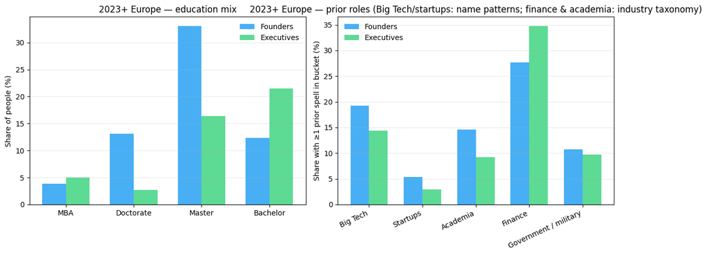

Pre-2023 vs 2023+ leadership (Europe): where the numbers differ

- **Tenure before joining the company (median years):** **pre-2023 matched founders** **8.6** (417 tenure-linked records) vs **2023+ leadership (pooled)** **14.2** (13813). **2023+ leadership (pooled)** is **5.7 years** higher on this median.

- **At least one prior Big Tech employer (name-pattern match):** **7.9%** (**35** / **442** people) for pre-2023 matched founders vs **14.4%** (**2001** / **13926**) for 2023+ leadership — **+6.5 percentage points** (2023+ leadership minus pre-2023).

- **At least one prior finance employer (financial-services industry taxonomy):** **41.9%** (**185** / **442**) vs **34.8%** (**4848** / **13926**) — **-7.0 points** (2023+ leadership minus pre-2023).

- **Highest pre-founding degree is Bachelor:** **16.1%** (**71** / **442**) vs **21.5%** (**2988** / **13926**) — **+5.4 points** (2023+ leadership minus pre-2023).

- **Highest pre-founding degree is MBA:** **8.6%** (**38** / **442**) vs **5.0%** (**694** / **13926**) — **-3.6 points** (2023+ leadership minus pre-2023).

- **Highest pre-founding degree is Doctorate:** **3.6%** (**16** / **442**) vs **2.7%** (**380** / **13926**) — **-0.9 points** (2023+ leadership minus pre-2023).

Top-line read — how to interpret the charts

- **Operating experience before the unicorn:** median pre-unicorn tenure is **8.6 years** among pre-2023 matched founders vs **14.2 years** for the 2023+ leadership pool (executives lift the pooled average because the roster is much larger and roles are more senior on average).

- **Education mix (2023+ Europe):** executives are **10.4 points** lower on **Doctorate** than matched founders.

- **Education mix (2023+ Europe):** executives are **16.7 points** lower on **Master** than matched founders.

- **Education mix (2023+ Europe):** executives are **9.1 points** higher on **Bachelor** than matched founders.

- **Prior roles (2023+ Europe):** vs matched founders, executives show a **+7.1 point** shift on **Finance** (Big Tech/startups use name patterns; finance and academia use industry taxonomy; overlap across buckets is possible).

- **Prior roles (2023+ Europe):** vs matched founders, executives show a **-5.4 point** shift on **Academia** (Big Tech/startups use name patterns; finance and academia use industry taxonomy; overlap across buckets is possible).

*Note: “Leadership pooled” mixes **matched founders** and **executives**; it is useful for “whole team” texture but is **not** interchangeable with a pure founder sample. Executive rows intentionally exclude in-unicorn positions when flagging prior roles.*

US exposure — pre-2023 matched founders (Europe)

- **Worked in the US (position country):** **106** / **442** people (**24.0%**).

- **Education with school country United States:** **93** / **406** people (**22.9%**).

Common career paths (first three role labels, Europe)

*Roles use the role taxonomy when available; otherwise job titles (uppercased). The table splits each path into three steps with wrapped text; the bar chart repeats the same ranking with shortened labels.*

**Pre-2023 matched founders**

| # | Role 1 (earliest) | Role 2 | Role 3 | People |
| --- | --- | --- | --- | --- |
| 1 | SOFTWARE ENGINEER | SOFTWARE ENGINEER | SOFTWARE ENGINEER | 20 |
| 2 | ENTREPRENEUR |  |  | 12 |
| 3 | ENTREPRENEUR | ENTREPRENEUR |  | 8 |
| 4 | BUSINESS DEVELOPMENT STRATEGIST | BUSINESS DEVELOPMENT STRATEGIST | BUSINESS DEVELOPMENT STRATEGIST | 8 |
| 5 | MARKETING COORDINATOR | MARKETING COORDINATOR | MARKETING COORDINATOR | 5 |
| 6 | SOFTWARE ENGINEER | SOFTWARE ENGINEER |  | 5 |
| 7 | ACADEMIC RESEARCHER | SOFTWARE ENGINEER | SOFTWARE ENGINEER | 4 |
| 8 | SOFTWARE ENGINEER | SOFTWARE ENGINEER | APPLICATION DEVELOPER | 4 |

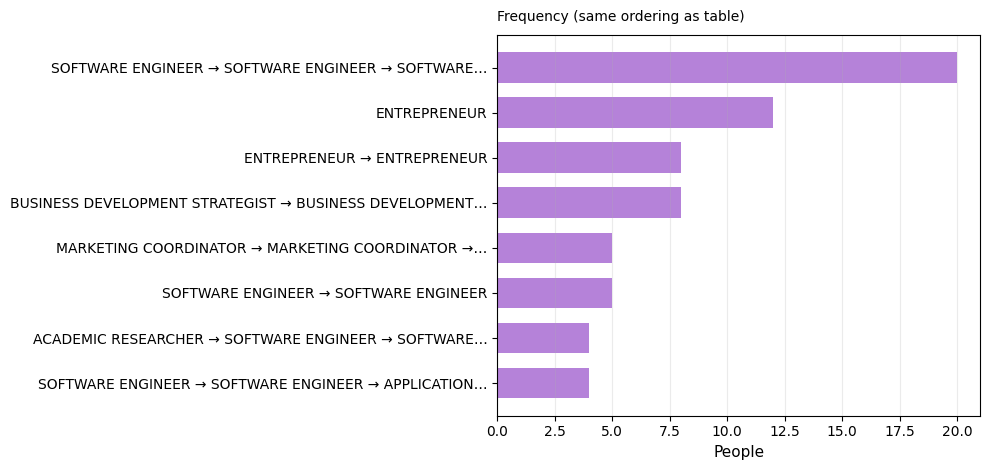

**2023+ matched founders**

| # | Role 1 (earliest) | Role 2 | Role 3 | People |
| --- | --- | --- | --- | --- |
| 1 | SOFTWARE ENGINEER | SOFTWARE ENGINEER | SOFTWARE ENGINEER | 3 |
| 2 | ENTREPRENEUR | ENTREPRENEUR | ENTREPRENEUR | 3 |
| 3 | DATA SCIENTIST | DATA SCIENTIST | DATA SCIENTIST | 3 |
| 4 | SOFTWARE ENGINEER | SOFTWARE ENGINEER | SOLUTIONS ARCHITECT | 2 |
| 5 | RESEARCH SCIENTIST | ACADEMIC RESEARCHER | ACADEMIC RESEARCHER | 2 |
| 6 | ACADEMIC RESEARCHER | RESEARCH SCIENTIST | ACADEMIC RESEARCHER | 2 |
| 7 | INVESTMENT ANALYST | BUSINESS DEVELOPMENT STRATEGIST | OPERATIONS COORDINATOR | 1 |
| 8 | RESEARCH SCIENTIST | CLINICAL TRIAL RESEARCHER | BUSINESS DEVELOPMENT STRATEGIST | 1 |

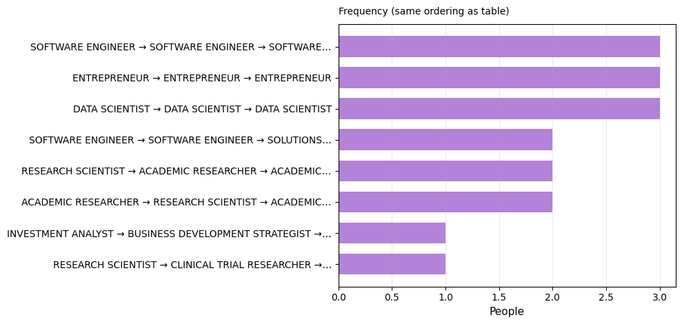

**2023+ executives (prior roles)**

| # | Role 1 (earliest) | Role 2 | Role 3 | People |
| --- | --- | --- | --- | --- |
| 1 | SOFTWARE ENGINEER | SOFTWARE ENGINEER | SOFTWARE ENGINEER | 292 |
| 2 | MARKETING COORDINATOR | MARKETING COORDINATOR | MARKETING COORDINATOR | 195 |
| 3 | INVESTMENT ANALYST | INVESTMENT ANALYST | INVESTMENT ANALYST | 101 |
| 4 | SALES ACCOUNT EXECUTIVE | SALES ACCOUNT EXECUTIVE | SALES ACCOUNT EXECUTIVE | 96 |
| 5 | HR OPERATIONS | HR OPERATIONS | HR OPERATIONS | 94 |
| 6 | CORPORATE ATTORNEY | CORPORATE ATTORNEY | CORPORATE ATTORNEY | 89 |
| 7 | ACCOUNTANT | ACCOUNTANT | ACCOUNTANT | 86 |
| 8 | CONTENT PRODUCER | CONTENT PRODUCER | CONTENT PRODUCER | 63 |

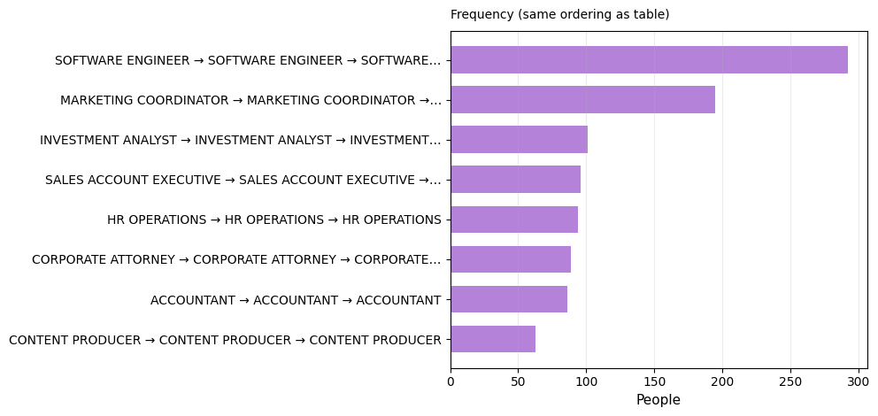